File: Hotel-Recommendations.ipynb  
Names: Corinne Medeiros  
Date: 10/18/20  
Usage: Program previews and summarizes Expedia Hotel Recommendations data, generates exploratory visualizations, and uses predictive models to predict hotel groups based on user data.

```python
import matplotlib
import matplotlib.pyplot as plt

import pandas as pd
import numpy as np

import seaborn as sns

import yellowbrick
from yellowbrick.features import Rank2D  # correlation visualization package
from yellowbrick.style import set_palette  # color for yellowbrick visualizer

from scipy.stats import spearmanr
from scipy.stats import kendalltau

from sklearn import preprocessing
from sklearn.model_selection import train_test_split
from sklearn.ensemble import RandomForestClassifier
from sklearn.metrics import classification_report, confusion_matrix, accuracy_score
from sklearn.naive_bayes import GaussianNB
```

# Creating Optimal Hotel Recommendations

### Objective: Predict which “hotel cluster” the user is likely to book, given their search details.

**Data source:**  
Expedia Hotel Recommendations  
https://www.kaggle.com/c/expedia-hotel-recommendations

[figure not shown]

## Loading and Exploring Data

To understand the data, I reviewed the columns and descriptions provided by the Kaggle data overview tab:

https://www.kaggle.com/c/expedia-hotel-recommendations/data?select=train.csv

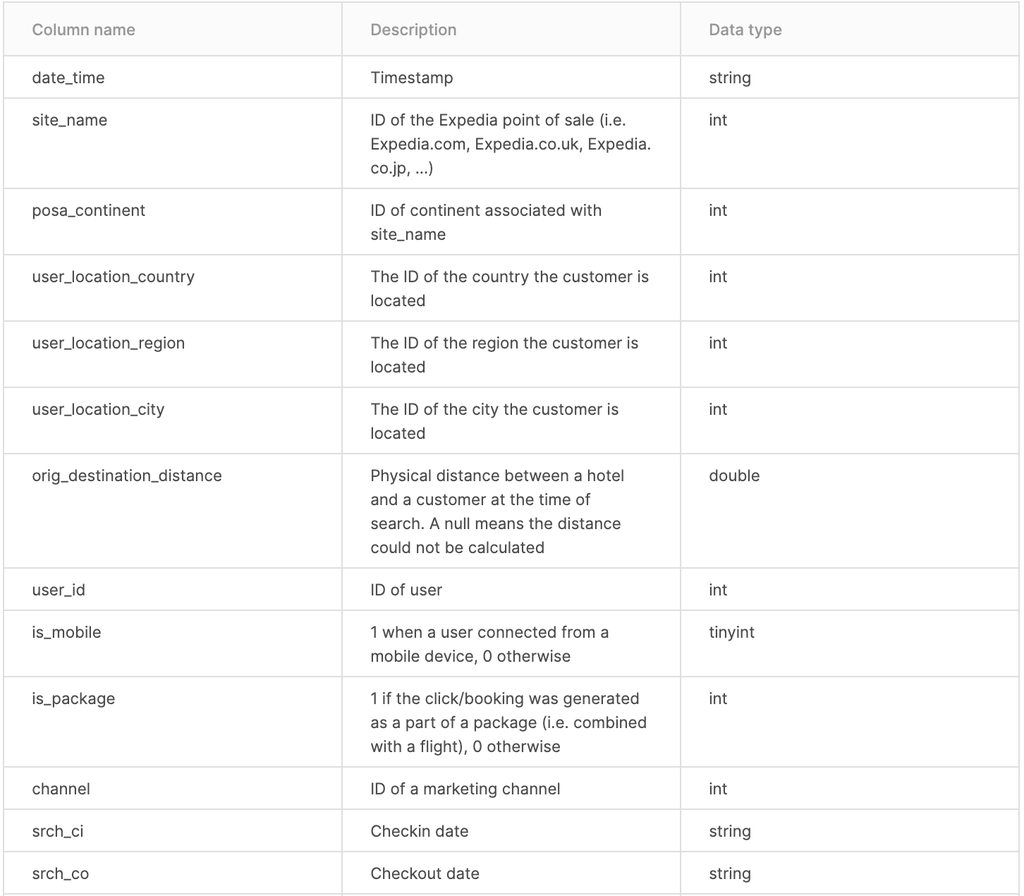

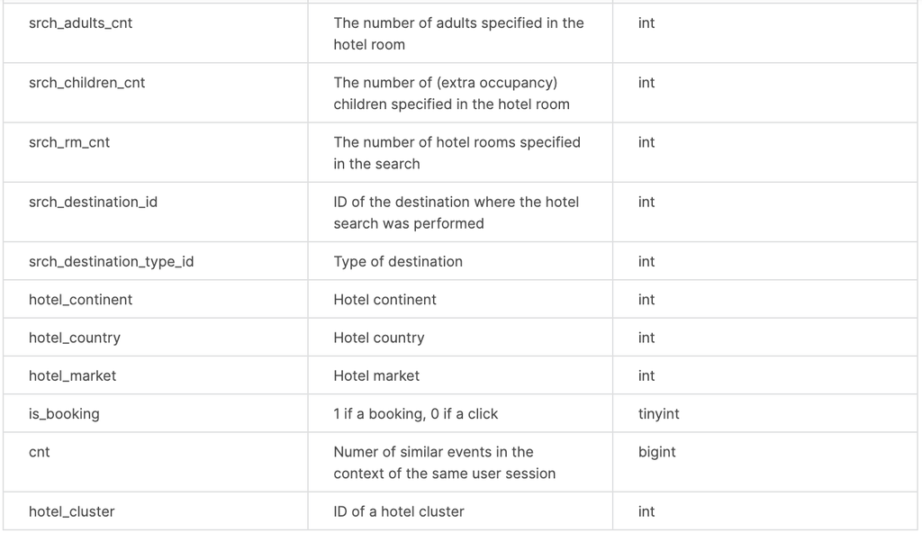

### Loading Data

The dataset is very large, with over 37 million observations, so I will only load a smaller subset.

Besides the target variable of hotel_cluster, the columns I'm going to explore are user_id, is_package, site_name, user_location_country, hotel_continent, srch_adults_cnt, srch_children_cnt, and srch_destination_id.

```python
# Loading subset of data into pandas dataframe, choosing columns and specifying data types
hotels_train_df = pd.read_csv('train.csv',
                              usecols=['user_id', 'is_package', 'site_name', 'user_location_country',
                                       'srch_adults_cnt', 'srch_children_cnt', 'srch_destination_id',
                                       'hotel_cluster', 'hotel_continent'],
                              dtype={'is_package':bool}, # changing data type to boolean
                              nrows = 500000)
```

```python
# Previewing data
hotels_train_df.head(10)
```

|  | site_name | user_location_country | user_id | is_package | srch_adults_cnt | srch_children_cnt | srch_destination_id | hotel_continent | hotel_cluster |
| --- | --- | --- | --- | --- | --- | --- | --- | --- | --- |
| 0 | 2 | 66 | 12 | True | 2 | 0 | 8250 | 2 | 1 |
| 1 | 2 | 66 | 12 | True | 2 | 0 | 8250 | 2 | 1 |
| 2 | 2 | 66 | 12 | False | 2 | 0 | 8250 | 2 | 1 |
| 3 | 2 | 66 | 93 | False | 2 | 0 | 14984 | 2 | 80 |
| 4 | 2 | 66 | 93 | False | 2 | 0 | 14984 | 2 | 21 |
| 5 | 2 | 66 | 93 | False | 2 | 0 | 14984 | 2 | 92 |
| 6 | 2 | 66 | 501 | False | 2 | 0 | 8267 | 2 | 41 |
| 7 | 2 | 66 | 501 | True | 2 | 0 | 8267 | 2 | 41 |
| 8 | 2 | 66 | 501 | False | 2 | 0 | 8267 | 2 | 69 |
| 9 | 2 | 66 | 501 | False | 2 | 0 | 8267 | 2 | 70 |

```python
# Summary of data
hotels_train_df.info()
```

```
<class 'pandas.core.frame.DataFrame'>
RangeIndex: 500000 entries, 0 to 499999
Data columns (total 9 columns):
site_name                500000 non-null int64
user_location_country    500000 non-null int64
user_id                  500000 non-null int64
is_package               500000 non-null bool
srch_adults_cnt          500000 non-null int64
srch_children_cnt        500000 non-null int64
srch_destination_id      500000 non-null int64
hotel_continent          500000 non-null int64
hotel_cluster            500000 non-null int64
dtypes: bool(1), int64(8)
memory usage: 31.0 MB
```

```python
# Summary information for columns
hotels_train_df.describe()
```

|  | site_name | user_location_country | user_id | srch_adults_cnt | srch_children_cnt | srch_destination_id | hotel_continent | hotel_cluster |
| --- | --- | --- | --- | --- | --- | --- | --- | --- |
| count | 500000.000000 | 500000.000000 | 5.000000e+05 | 500000.000000 | 500000.000000 | 500000.000000 | 500000.000000 | 500000.000000 |
| mean | 9.596348 | 84.890906 | 5.192133e+05 | 2.029878 | 0.328476 | 14520.732588 | 3.211660 | 49.821640 |
| std | 12.209567 | 55.099574 | 3.399832e+05 | 0.918030 | 0.729282 | 11074.285557 | 1.657219 | 28.956834 |
| min | 2.000000 | 0.000000 | 1.200000e+01 | 0.000000 | 0.000000 | 1.000000 | 0.000000 | 0.000000 |
| 25% | 2.000000 | 66.000000 | 2.156960e+05 | 2.000000 | 0.000000 | 8267.000000 | 2.000000 | 25.000000 |
| 50% | 2.000000 | 66.000000 | 4.443650e+05 | 2.000000 | 0.000000 | 9927.000000 | 2.000000 | 49.000000 |
| 75% | 13.000000 | 69.000000 | 8.135170e+05 | 2.000000 | 0.000000 | 18965.000000 | 4.000000 | 73.000000 |
| max | 53.000000 | 239.000000 | 1.198784e+06 | 9.000000 | 9.000000 | 65035.000000 | 6.000000 | 99.000000 |

```python
# Summary information for columns without scientific notation

with pd.option_context('float_format', '{:f}'.format):
    print(hotels_train_df.describe())
```

```
          site_name  user_location_country        user_id  srch_adults_cnt  \
count 500000.000000          500000.000000  500000.000000    500000.000000
mean       9.596348              84.890906  519213.302920         2.029878
std       12.209567              55.099574  339983.175557         0.918030
min        2.000000               0.000000      12.000000         0.000000
25%        2.000000              66.000000  215696.000000         2.000000
50%        2.000000              66.000000  444365.000000         2.000000
75%       13.000000              69.000000  813517.000000         2.000000
max       53.000000             239.000000 1198784.000000         9.000000

       srch_children_cnt  srch_destination_id  hotel_continent  hotel_cluster
count      500000.000000        500000.000000    500000.000000  500000.000000
mean            0.328476         14520.732588         3.211660      49.821640
std             0.729282         11074.285557         1.657219      28.956834
min             0.000000             1.000000         0.000000       0.000000
25%             0.000000          8267.000000         2.000000      25.000000
50%             0.000000          9927.000000         2.000000      49.000000
75%             0.000000         18965.000000         4.000000      73.000000
max             9.000000         65035.000000         6.000000      99.000000
```

```python
# Displaying summary information for boolean 'is_package' column
print(hotels_train_df.describe(include=[bool]))
```

```
       is_package
count      500000
unique          2
top         False
freq       372236
```

```python
# Checking missing data sums
hotels_train_df.isna().sum()
```

```
site_name                0
user_location_country    0
user_id                  0
is_package               0
srch_adults_cnt          0
srch_children_cnt        0
srch_destination_id      0
hotel_continent          0
hotel_cluster            0
dtype: int64
```

### Exploratory Visualizations

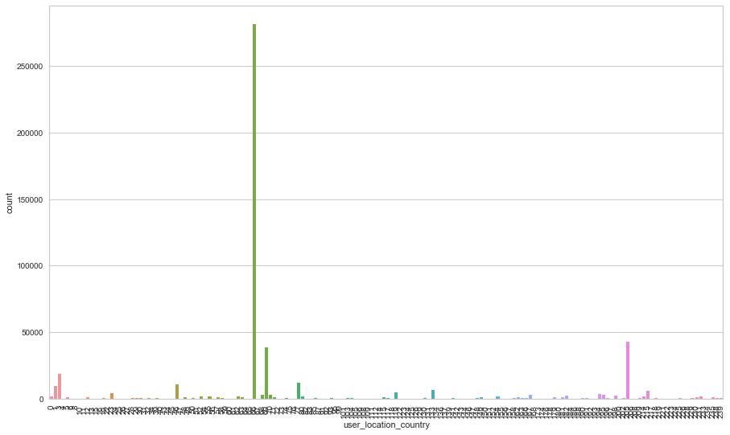

```python
# User country frequency using seaborn countplot

plt.figure(figsize=(15, 9))
plt.xticks(rotation=90)
sns.countplot(x='user_location_country', data=hotels_train_df)
```

From this bar graph as well as the data quartile range summary statistics, even though the x-axis in this graph is too crowded to read, we can tell that the vast majority of our users in this subset represent country 66. I will confirm this with further plotting next.

This may be a bias introduced from only selecting a subset, so for future exploration I could try selecting another subset, or loading all of the data in chunks in order to see if the data represent a more diverse sample. For the purposes of this assignment and learning, I'm going to stick with this smaller subset.

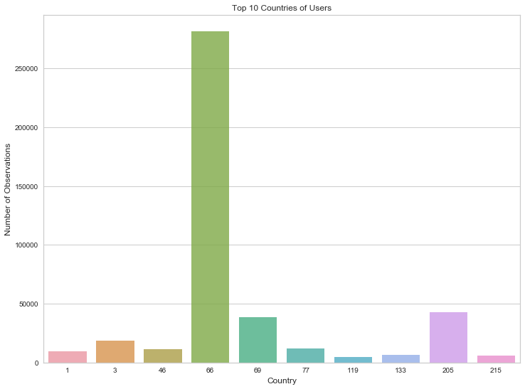

```python
# Bar graph of the number of users in each country for the top ten countries

# Selecting and storing user country column
country_count = hotels_train_df['user_location_country'].value_counts()

# Limiting to top 10 countries
countries_topten = country_count[:10,]

plt.figure(figsize=(12,9))
sns.barplot(countries_topten.index, countries_topten.values, alpha=0.8)
plt.title('Top 10 Countries of Users')
plt.ylabel('Number of Observations', fontsize=12)
plt.xlabel('Country', fontsize=12)
plt.show()
```

After limiting the data to the top ten country count values, we can clearly confirm that our users mostly come from country 66.

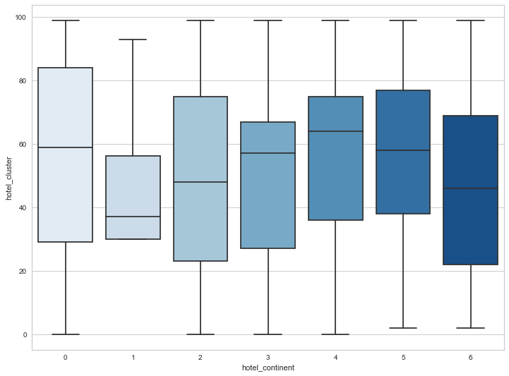

```python
# Boxplot of hotel cluster by hotel continent

plt.figure(figsize=(12,9))
sns.boxplot(x = hotels_train_df["hotel_continent"], y = hotels_train_df["hotel_cluster"], palette="Blues");
plt.show()
```

Interpreting this box plot is difficult because the data are not represented very well. Hotel cluster is more of a discrete categorical variable and this treats it as continuous, which isn't very helpful. We can see that continent 0 represents a wider range of hotel clusters while continent 1 represents a smaller range, but we don't have enough information on the hotel clusters themselves to make this insight useful. I'm going to try looking at frequency of hotel clusters instead.

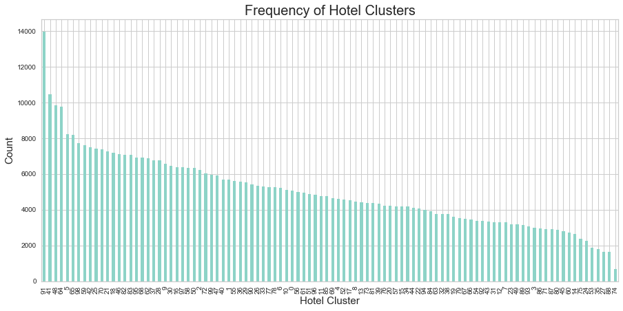

```python
# Plot frequency of each hotel cluster

hotels_train_df["hotel_cluster"].value_counts().plot(kind='bar',colormap="Set3",figsize=(15,7))
plt.xlabel('Hotel Cluster', fontsize=15)
plt.ylabel('Count', fontsize=15)
plt.title('Frequency of Hotel Clusters', fontsize=20)
plt.show()
```

From this bar chart we can see that hotel clusters 91 and 41 are the most frequent groups, and the least common group is cluster 74.

### Checking Correlation

I'm going to calculate correlation to get a sense of the relationships between some of the variables, which will help in data understanding and determining which predictive models might be most effective.

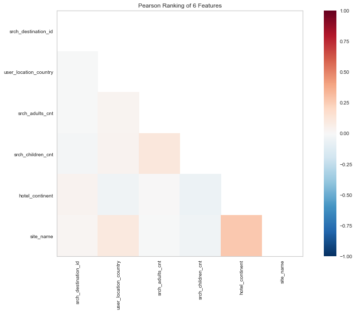

```python
# Pearson Ranking

# Setting up figure size
plt.rcParams['figure.figsize'] = (15, 9)

# Choosing attributes to compare
features = ['srch_destination_id', 'user_location_country', 'srch_adults_cnt', 'srch_children_cnt',
            'hotel_continent', 'site_name']

# Extracting numpy arrays
X = hotels_train_df[features].values

# Instantiating, fitting, and transforming the visualizer with covariance ranking algorithm
visualizer = Rank2D(features=features, algorithm='pearson')
visualizer.fit(X)
visualizer.transform(X)
visualizer.poof(outpath="pearson_ranking.png") # Drawing the data and saving the output
plt.show()
```

It looks like the strongest correlation is a positive relationship of about ~0.25 between hotel continent and site name. The other relationships are also not statistically significant. This tells us that we don't have to worry about multicollinearity when choosing predictive models.

## Predictive Modeling

Since we are trying to predict the unique hotel cluster, we are dealing with a multi-class classification problem. First, I will look at how many hotel clusters exist.

```python
# Convert hotel_cluster column to string
hotel_clusters = hotels_train_df['hotel_cluster'].astype(str)
```

```python
hotel_clusters.describe(include=['O'])
```

```
count     500000
unique       100
top           91
freq       13958
Name: hotel_cluster, dtype: object
```

Our target variable, hotel_cluster, consists of 100 unique values.

### Splitting 'hotels_train_df' into train and test set

```python
# Splitting the data into independent and dependent variables

features = ['srch_destination_id', 'user_location_country', 'srch_adults_cnt', 'srch_children_cnt',
            'hotel_continent', 'site_name']

X = hotels_train_df[features].values
y = hotels_train_df['hotel_cluster'].values
```

```python
# Creating the Training and Test set from data
X_train, X_test, y_train, y_test = train_test_split(X, y, test_size = 0.25, random_state = 21)

# Number of samples in each set
print("No. of samples in training set: ", X_train.shape[0])
print("No. of samples in test set:", X_test.shape[0])
```

```
No. of samples in training set:  375000
No. of samples in test set: 125000
```

### Random Forest Classifier

I chose to use a random forest classifier because it's a more accurate ensemble of trees, less biased, and I'm working with a larger amount of data.

```python
# Fitting Random Forest Classification to the Training set
classifier = RandomForestClassifier(n_estimators = 10, criterion = 'entropy', random_state = 42)
classifier.fit(X_train, y_train)
```

```
RandomForestClassifier(bootstrap=True, class_weight=None, criterion='entropy',
                       max_depth=None, max_features='auto', max_leaf_nodes=None,
                       min_impurity_decrease=0.0, min_impurity_split=None,
                       min_samples_leaf=1, min_samples_split=2,
                       min_weight_fraction_leaf=0.0, n_estimators=10,
                       n_jobs=None, oob_score=False, random_state=42, verbose=0,
                       warm_start=False)
```

### Evaluating Random Forest Classifier

```python
# Predicting test set results
y_pred = classifier.predict(X_test)

# Confusion Matrix
pd.crosstab(y_test, y_pred, rownames=['Actual Hotel Cluster'], colnames=['Predicted Hotel Cluster'])
```

| Predicted Hotel Cluster Actual Hotel Cluster | 0 | 1 | 2 | 3 | 4 | 5 | 6 | 7 | 8 | 9 | ... | 90 | 91 | 92 | 93 | 94 | 95 | 96 | 97 | 98 | 99 |
| --- | --- | --- | --- | --- | --- | --- | --- | --- | --- | --- | --- | --- | --- | --- | --- | --- | --- | --- | --- | --- | --- |
| 0 | 499 | 5 | 0 | 1 | 6 | 7 | 7 | 0 | 0 | 4 | ... | 5 | 18 | 6 | 0 | 1 | 20 | 38 | 3 | 0 | 0 |
| 1 | 1 | 1236 | 0 | 0 | 2 | 0 | 0 | 0 | 0 | 0 | ... | 0 | 2 | 0 | 0 | 0 | 0 | 0 | 0 | 0 | 0 |
| 2 | 0 | 0 | 349 | 2 | 9 | 30 | 8 | 4 | 25 | 24 | ... | 14 | 48 | 2 | 3 | 3 | 93 | 0 | 47 | 28 | 28 |
| 3 | 5 | 0 | 10 | 94 | 3 | 11 | 4 | 1 | 4 | 6 | ... | 12 | 12 | 3 | 6 | 0 | 10 | 3 | 2 | 3 | 7 |
| 4 | 10 | 0 | 5 | 5 | 199 | 7 | 19 | 3 | 3 | 12 | ... | 3 | 52 | 0 | 3 | 3 | 91 | 4 | 10 | 26 | 8 |
| 5 | 39 | 0 | 45 | 7 | 16 | 329 | 12 | 6 | 34 | 33 | ... | 23 | 48 | 1 | 10 | 6 | 34 | 17 | 26 | 14 | 25 |
| 6 | 21 | 0 | 13 | 1 | 21 | 23 | 211 | 1 | 12 | 26 | ... | 5 | 68 | 1 | 2 | 4 | 42 | 8 | 6 | 11 | 22 |
| 7 | 3 | 0 | 3 | 3 | 5 | 12 | 10 | 167 | 15 | 4 | ... | 6 | 73 | 1 | 11 | 8 | 6 | 1 | 7 | 0 | 3 |
| 8 | 2 | 0 | 5 | 2 | 6 | 24 | 6 | 3 | 441 | 9 | ... | 7 | 7 | 8 | 6 | 0 | 4 | 8 | 16 | 2 | 18 |
| 9 | 65 | 0 | 33 | 0 | 12 | 19 | 8 | 0 | 32 | 302 | ... | 14 | 34 | 8 | 1 | 1 | 107 | 3 | 34 | 40 | 42 |
| 10 | 21 | 33 | 19 | 4 | 12 | 32 | 14 | 12 | 18 | 26 | ... | 8 | 41 | 4 | 3 | 1 | 23 | 4 | 12 | 13 | 23 |
| 11 | 18 | 0 | 43 | 1 | 4 | 41 | 6 | 4 | 17 | 18 | ... | 2 | 18 | 1 | 2 | 2 | 19 | 3 | 52 | 10 | 9 |
| 12 | 3 | 2 | 7 | 0 | 0 | 13 | 6 | 6 | 1 | 1 | ... | 0 | 1 | 3 | 0 | 0 | 1 | 0 | 4 | 0 | 8 |
| 13 | 16 | 0 | 6 | 0 | 8 | 9 | 12 | 14 | 2 | 20 | ... | 7 | 88 | 0 | 3 | 5 | 28 | 8 | 5 | 12 | 5 |
| 14 | 2 | 2 | 4 | 2 | 2 | 13 | 8 | 6 | 26 | 3 | ... | 7 | 29 | 0 | 3 | 11 | 12 | 2 | 4 | 2 | 7 |
| 15 | 8 | 5 | 15 | 2 | 5 | 10 | 21 | 14 | 11 | 16 | ... | 12 | 63 | 1 | 3 | 6 | 2 | 4 | 11 | 0 | 22 |
| 16 | 16 | 0 | 19 | 6 | 20 | 23 | 29 | 10 | 3 | 8 | ... | 9 | 129 | 5 | 4 | 28 | 54 | 3 | 8 | 11 | 11 |
| 17 | 34 | 1 | 15 | 2 | 30 | 26 | 6 | 1 | 7 | 21 | ... | 5 | 34 | 2 | 4 | 0 | 21 | 11 | 16 | 30 | 4 |
| 18 | 39 | 71 | 28 | 5 | 22 | 11 | 21 | 6 | 0 | 38 | ... | 6 | 165 | 0 | 3 | 16 | 181 | 11 | 9 | 39 | 13 |
| 19 | 25 | 102 | 1 | 1 | 23 | 4 | 7 | 2 | 0 | 8 | ... | 2 | 37 | 2 | 0 | 1 | 100 | 5 | 1 | 20 | 4 |
| 20 | 10 | 0 | 7 | 17 | 1 | 16 | 2 | 2 | 20 | 9 | ... | 13 | 10 | 4 | 6 | 0 | 2 | 2 | 5 | 3 | 7 |
| 21 | 57 | 0 | 42 | 0 | 23 | 19 | 10 | 1 | 6 | 30 | ... | 7 | 60 | 0 | 2 | 4 | 159 | 13 | 64 | 64 | 15 |
| 22 | 2 | 0 | 14 | 5 | 3 | 29 | 5 | 1 | 93 | 7 | ... | 7 | 11 | 12 | 4 | 1 | 5 | 3 | 7 | 0 | 27 |
| 23 | 10 | 3 | 5 | 1 | 26 | 8 | 7 | 3 | 0 | 4 | ... | 3 | 44 | 0 | 0 | 3 | 28 | 3 | 5 | 8 | 0 |
| 24 | 0 | 455 | 0 | 0 | 0 | 0 | 0 | 1 | 0 | 0 | ... | 0 | 2 | 0 | 0 | 0 | 0 | 0 | 0 | 0 | 0 |
| 25 | 20 | 0 | 47 | 1 | 17 | 43 | 11 | 2 | 14 | 33 | ... | 9 | 40 | 5 | 6 | 3 | 54 | 9 | 73 | 49 | 16 |
| 26 | 124 | 0 | 3 | 2 | 3 | 0 | 1 | 2 | 3 | 2 | ... | 2 | 33 | 24 | 3 | 1 | 4 | 31 | 4 | 3 | 1 |
| 27 | 0 | 0 | 0 | 0 | 0 | 0 | 0 | 0 | 5 | 0 | ... | 0 | 0 | 2 | 0 | 1 | 0 | 0 | 2 | 0 | 0 |
| 28 | 23 | 0 | 27 | 1 | 32 | 12 | 15 | 6 | 10 | 35 | ... | 17 | 151 | 0 | 2 | 16 | 66 | 5 | 6 | 18 | 7 |
| 29 | 0 | 0 | 70 | 2 | 0 | 49 | 6 | 3 | 8 | 7 | ... | 6 | 2 | 0 | 5 | 0 | 4 | 0 | 14 | 1 | 13 |
| ... | ... | ... | ... | ... | ... | ... | ... | ... | ... | ... | ... | ... | ... | ... | ... | ... | ... | ... | ... | ... | ... |
| 70 | 14 | 1 | 7 | 2 | 14 | 11 | 2 | 2 | 7 | 37 | ... | 2 | 70 | 2 | 2 | 3 | 57 | 5 | 46 | 121 | 5 |
| 71 | 20 | 161 | 0 | 1 | 0 | 1 | 0 | 0 | 0 | 0 | ... | 5 | 12 | 0 | 1 | 1 | 4 | 6 | 0 | 0 | 0 |
| 72 | 32 | 0 | 18 | 1 | 20 | 27 | 10 | 6 | 2 | 32 | ... | 5 | 111 | 1 | 6 | 12 | 91 | 13 | 6 | 31 | 6 |
| 73 | 43 | 0 | 7 | 4 | 0 | 14 | 3 | 4 | 4 | 6 | ... | 28 | 14 | 16 | 5 | 2 | 20 | 16 | 15 | 22 | 6 |
| 74 | 0 | 0 | 0 | 0 | 0 | 0 | 0 | 0 | 0 | 0 | ... | 0 | 0 | 0 | 0 | 0 | 0 | 0 | 0 | 0 | 0 |
| 75 | 12 | 0 | 3 | 2 | 5 | 7 | 8 | 4 | 9 | 5 | ... | 8 | 10 | 5 | 3 | 0 | 8 | 8 | 5 | 3 | 8 |
| 76 | 14 | 3 | 2 | 4 | 12 | 10 | 13 | 7 | 10 | 10 | ... | 3 | 46 | 1 | 2 | 11 | 22 | 7 | 16 | 7 | 8 |
| 77 | 4 | 0 | 8 | 1 | 9 | 4 | 13 | 9 | 6 | 7 | ... | 6 | 88 | 0 | 4 | 5 | 18 | 8 | 10 | 6 | 4 |
| 78 | 1 | 6 | 15 | 12 | 0 | 19 | 2 | 2 | 71 | 2 | ... | 19 | 2 | 6 | 8 | 1 | 3 | 5 | 9 | 0 | 30 |
| 79 | 7 | 604 | 0 | 0 | 2 | 1 | 2 | 1 | 0 | 0 | ... | 0 | 0 | 0 | 0 | 0 | 0 | 2 | 0 | 0 | 0 |
| 80 | 59 | 0 | 1 | 1 | 2 | 6 | 3 | 0 | 1 | 0 | ... | 7 | 4 | 21 | 0 | 0 | 8 | 4 | 0 | 1 | 1 |
| 81 | 0 | 3 | 5 | 9 | 0 | 4 | 14 | 3 | 23 | 3 | ... | 4 | 3 | 2 | 4 | 1 | 0 | 0 | 2 | 0 | 8 |
| 82 | 0 | 0 | 40 | 9 | 2 | 22 | 12 | 5 | 17 | 8 | ... | 13 | 5 | 0 | 3 | 0 | 1 | 0 | 5 | 3 | 40 |
| 83 | 67 | 15 | 8 | 3 | 11 | 44 | 10 | 5 | 10 | 30 | ... | 5 | 82 | 1 | 4 | 12 | 43 | 7 | 15 | 32 | 15 |
| 84 | 79 | 70 | 1 | 1 | 3 | 6 | 1 | 1 | 2 | 1 | ... | 1 | 29 | 30 | 0 | 2 | 12 | 23 | 9 | 1 | 1 |
| 85 | 3 | 0 | 17 | 11 | 0 | 29 | 4 | 9 | 10 | 9 | ... | 10 | 3 | 1 | 4 | 0 | 2 | 0 | 4 | 4 | 19 |
| 86 | 12 | 0 | 6 | 0 | 3 | 8 | 0 | 0 | 15 | 1 | ... | 1 | 6 | 19 | 2 | 2 | 8 | 5 | 17 | 4 | 4 |
| 87 | 4 | 0 | 0 | 2 | 0 | 2 | 4 | 0 | 1 | 1 | ... | 1 | 2 | 0 | 1 | 0 | 0 | 4 | 5 | 6 | 8 |
| 88 | 0 | 325 | 0 | 0 | 1 | 0 | 0 | 0 | 0 | 0 | ... | 0 | 0 | 0 | 0 | 1 | 0 | 0 | 0 | 0 | 0 |
| 89 | 17 | 2 | 11 | 3 | 6 | 11 | 3 | 6 | 27 | 0 | ... | 9 | 20 | 1 | 5 | 4 | 23 | 8 | 14 | 4 | 7 |
| 90 | 19 | 18 | 14 | 6 | 9 | 25 | 8 | 7 | 16 | 9 | ... | 181 | 43 | 6 | 18 | 4 | 19 | 19 | 15 | 10 | 13 |
| 91 | 40 | 44 | 21 | 3 | 33 | 20 | 39 | 23 | 6 | 33 | ... | 30 | 1036 | 3 | 6 | 87 | 143 | 19 | 11 | 20 | 11 |
| 92 | 28 | 11 | 0 | 1 | 0 | 3 | 1 | 1 | 1 | 2 | ... | 1 | 12 | 279 | 4 | 0 | 3 | 9 | 9 | 0 | 1 |
| 93 | 21 | 0 | 8 | 11 | 9 | 12 | 5 | 3 | 13 | 15 | ... | 25 | 46 | 7 | 78 | 4 | 18 | 9 | 3 | 3 | 6 |
| 94 | 19 | 23 | 7 | 0 | 6 | 10 | 10 | 13 | 2 | 3 | ... | 6 | 168 | 3 | 2 | 135 | 38 | 12 | 4 | 6 | 2 |
| 95 | 15 | 0 | 40 | 4 | 35 | 7 | 15 | 0 | 3 | 66 | ... | 9 | 100 | 2 | 4 | 4 | 549 | 19 | 21 | 72 | 11 |
| 96 | 152 | 9 | 0 | 6 | 8 | 5 | 1 | 0 | 1 | 2 | ... | 13 | 41 | 9 | 3 | 2 | 38 | 145 | 0 | 1 | 8 |
| 97 | 20 | 0 | 31 | 2 | 9 | 22 | 0 | 1 | 20 | 36 | ... | 5 | 28 | 12 | 2 | 3 | 47 | 3 | 336 | 51 | 8 |
| 98 | 21 | 1 | 37 | 3 | 20 | 9 | 6 | 0 | 3 | 60 | ... | 2 | 31 | 1 | 4 | 0 | 147 | 7 | 81 | 348 | 6 |
| 99 | 9 | 3 | 35 | 3 | 13 | 25 | 15 | 4 | 76 | 31 | ... | 3 | 26 | 2 | 3 | 2 | 50 | 5 | 18 | 10 | 268 |

100 rows × 100 columns

```python
# Confusion Matrix
confusion_matrix(y_test,y_pred)
```

```
array([[ 499,    5,    0, ...,    3,    0,    0],
       [   1, 1236,    0, ...,    0,    0,    0],
       [   0,    0,  349, ...,   47,   28,   28],
       ...,
       [  20,    0,   31, ...,  336,   51,    8],
       [  21,    1,   37, ...,   81,  348,    6],
       [   9,    3,   35, ...,   18,   10,  268]])
```

In these two methods of displaying the confusion matrix, we can see that there are a good amount of high values across the diagonal section, which is a good sign. However, in the larger version we can also see that there are high values dispersed throughout the sides as well which means there are a lot of incorrect predictions.

```python
# Classification Report
print("Classification Report:\n\n", classification_report(y_test,y_pred))
```

```
Classification Report:

               precision    recall  f1-score   support

           0       0.20      0.40      0.26      1237
           1       0.27      0.86      0.41      1434
           2       0.20      0.24      0.22      1476
           3       0.22      0.13      0.16       722
           4       0.19      0.18      0.19      1116
           5       0.19      0.16      0.17      2024
           6       0.21      0.16      0.18      1311
           7       0.28      0.20      0.23       844
           8       0.26      0.39      0.31      1144
           9       0.18      0.18      0.18      1633
          10       0.18      0.12      0.15      1298
```

[output cut: 93 more lines]

```python
# Accuracy of model
print("Accuracy:", accuracy_score(y_test, y_pred))
```

```
Accuracy: 0.220376
```

### Naive Bayes Classifier

I'm going to try a Naive Bayes Classifier next, since my features are independent and because it tends to perform well with multiple classes.

```python
# Training Naive Bayes classifier
gnb = GaussianNB().fit(X_train, y_train)
gnb_predictions = gnb.predict(X_test)
```

### Evaluating Naive Bayes Classifier

```python
# Accuracy
accuracy = gnb.score(X_test, y_test)
print("Accuracy:", accuracy)
```

```
Accuracy: 0.054088
```

```python
# Confusion matrix
confusion_matrix(y_test, gnb_predictions)
```

```
array([[   0,  452,    0, ...,    0,    0,    0],
       [   0, 1080,    0, ...,    0,    0,    0],
       [  18,  198,    0, ...,    0,   29,    0],
       ...,
       [  65,  407,    0, ...,    0,    7,    0],
       [  15,  830,    0, ...,    0,   60,    0],
       [  40,  199,    0, ...,    0,   14,    0]])
```

## Results

Overall, my predictive models performed quite poorly. The Random Forest Classifier resulted in a 22% accuracy and the Naive Bayes Classifer only gave a 5% accuracy. The highest precision score from the Random Forest Classifier was 91% for hotel cluster 74, but the rest were mostly very low. To improve predictive power, I think it would help to have more information on what the attributes represent. For example, it would be nice to know how the hotel groups are determined and which locations correspond to country and continent numbers. This way, the results might be more interpretable. In addition, I could experiment with a different combination of features and different parameters when modeling. Finally, I could try building different ensembles of models to try achieving better accuracy and interpretability.